# monet_fticr

Alan Roebuck

2024-04-10

### *Initial Data Curation*

#### *Read in Metadata and Land Cover Data*

#### *Read in FTICR-MS data and generate relevant moleular information*

This section reads in FTICRMS data from 1000 soils project. It then separates into 2 data frames - 1 called ‘mol’ that contains the molecular properties data for all of the peaks identified in the data set. This information is calculated from the elemental formula identified within the dataset.

The second dataframe is called data which contains the presence absence of individual identified peaks within each sample.

Disclaimer: This section bins FTICRMS data into common biomolecular classes based on groupings by Kim et al., 2003. It is important to recognize that relating a molecular formula to one of these biomolecular classes DOES NOT confirm structure for that molecular formula, it ONLY indicates a stoichiometric similarity to what would be reasonably expected for those types of biomolecules.

#### *Read in 1000 soils geochemistry data*

#### *Calculate Sample-level FTICRMS molecular properties*

This section calculates the average molecular properties for each individual sample. For instance, a single sample may have 1000 identified formula, each assigned a carbon value. The sample average is the average carbon value from those 1000 identified molecular formula. Note, each sample will have variable amounts of identified formula. The average is unique only to what is present in the sample.

### Question 1: How spatially variable is water extractable SOM composition at the CONUS scale? What are the drivers of such variability?

#### **Hypothesis 1: Land cover/Land use are important drivers of SOM composition variability. (e.g., distinct compositional differences between forest and grasslands)**

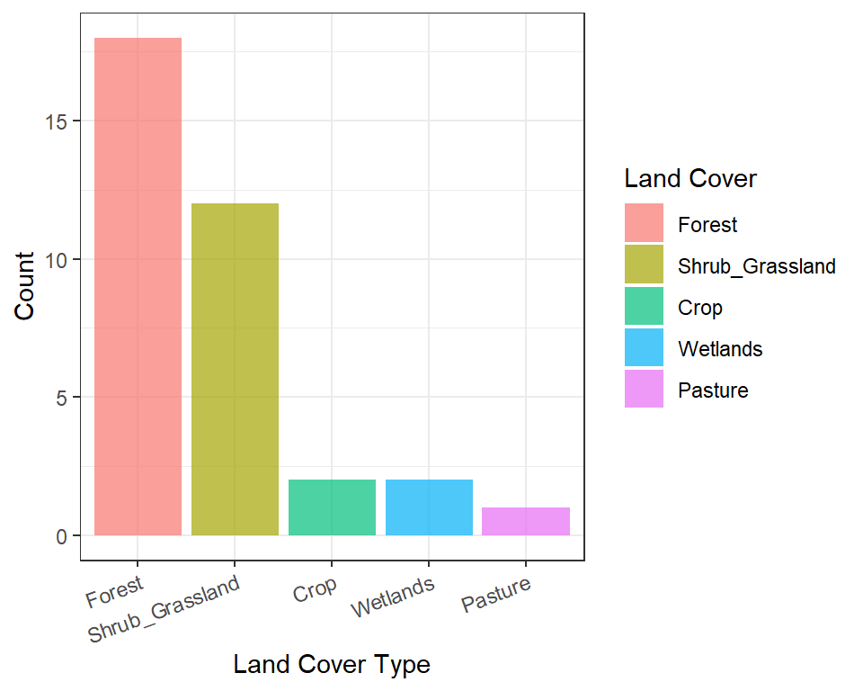

##### *Figure 2: NMDS evaluating distribution of sites based on their molecular make-up (FTICR-MS) and relationships with land use*

##### *Perform NMDS ordination analysis*

##### *Create Individual Figures for the top and bottom layers*

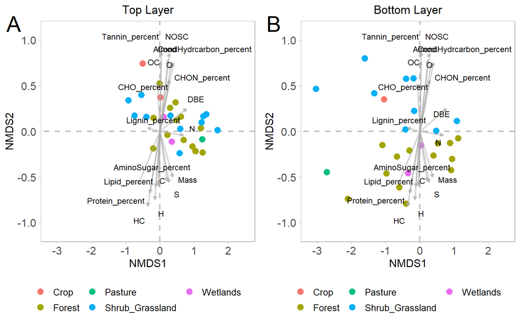

##### *Figure 3: Boxplots of FTICRMS molecular properties for BTM layer*

##### *Generate function for baseline boxplot graphs*

This chunk creates a generic ggplot code that will be applied to make a number of equivalent graphs where the only variable changing is the y-axis

##### *Generate boxplots*

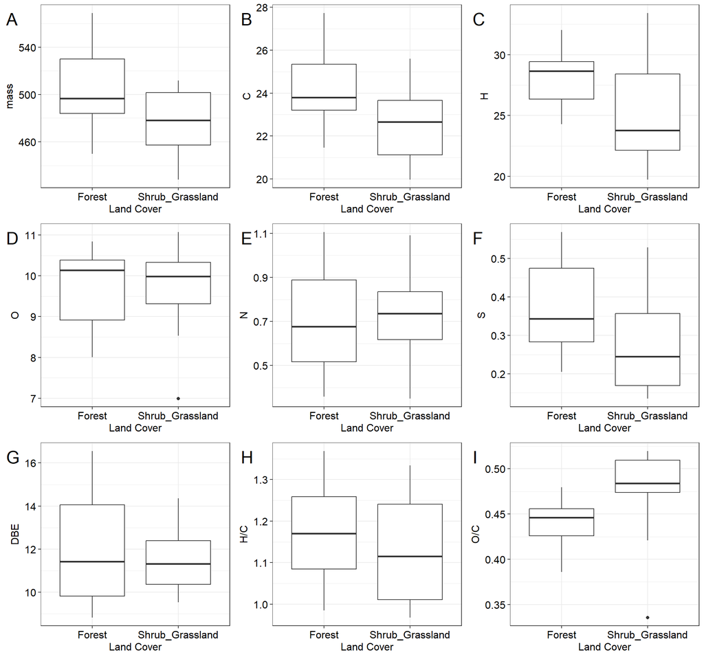

#### **Hypothesis 2: Soil texture will influence C availability and composition. Higher clay content will lead to lower WEOM concentrations and different composition than sand dominated soils**

##### *Figure 4a: Soil Texture Density Plots*

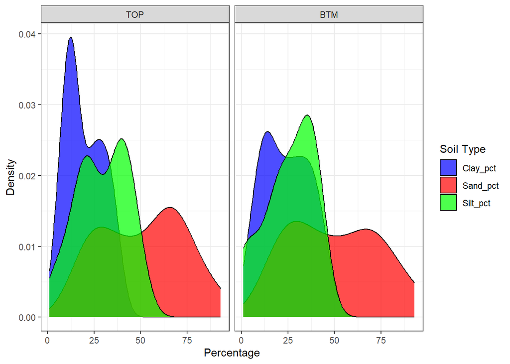

##### *Figure 4b: Soil Texture as a function of Land Use*

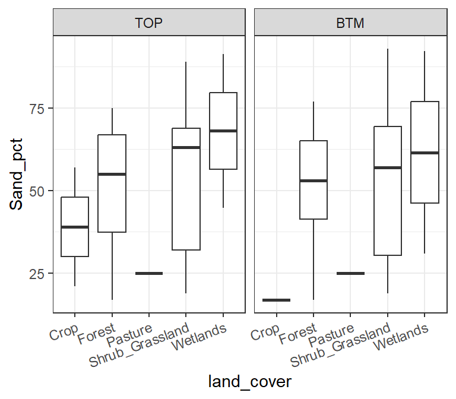

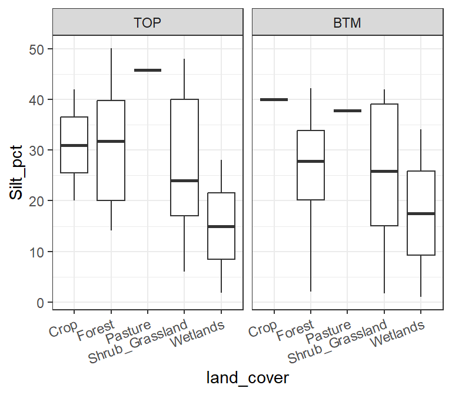

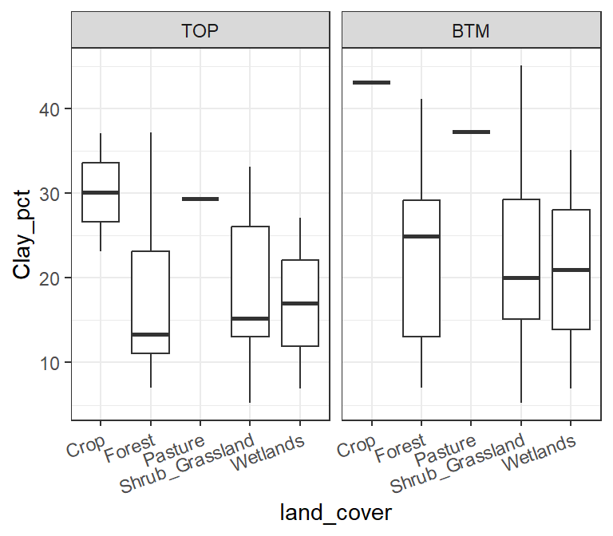

##### *Figure 5: NMDS with soil texture features*

Note, this will use previously created NMDS, but will simply have the soil texture features envirofitted onto the graph. Only features significant to p < 0.05 will be displayed.

In this case, Clay percentage is only signficant and is very weak (p = 0.04)

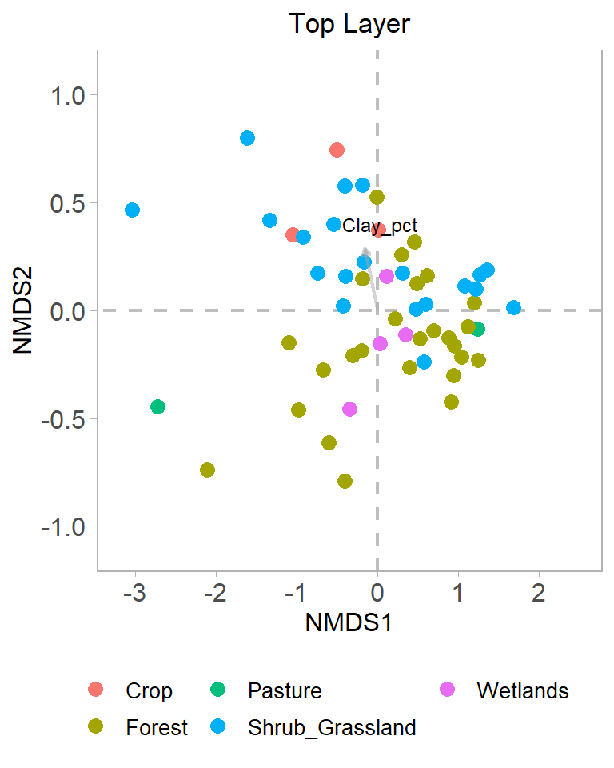

##### *Figure 6: Molecular Properties as a funciton of soil texture*

Here, plotted Aromaticity index, H/C ratio, O/C ratio, and N as a function of Clay and Sand percentages - No clear relationships stand out between the soil texture and molecular properties.

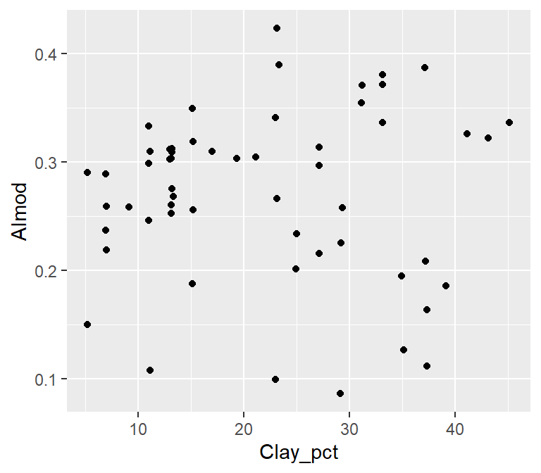

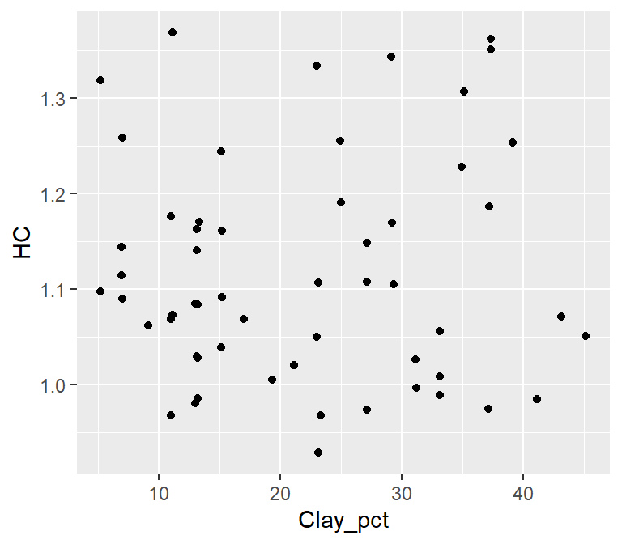

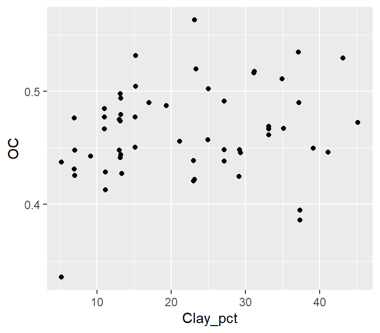

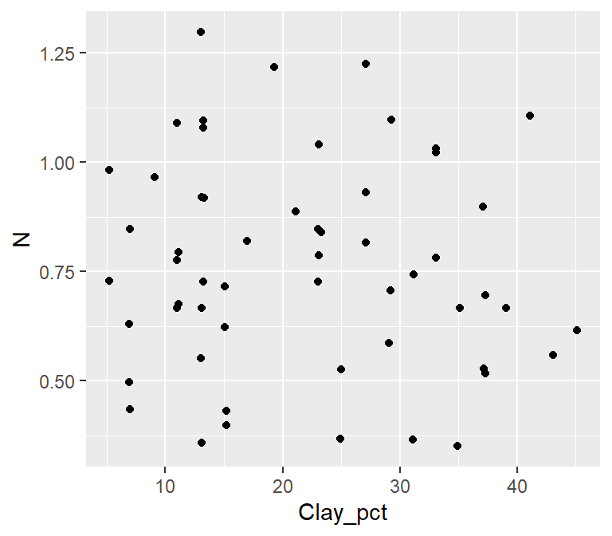

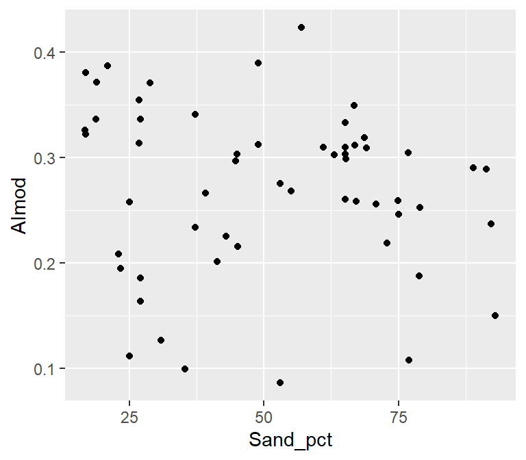

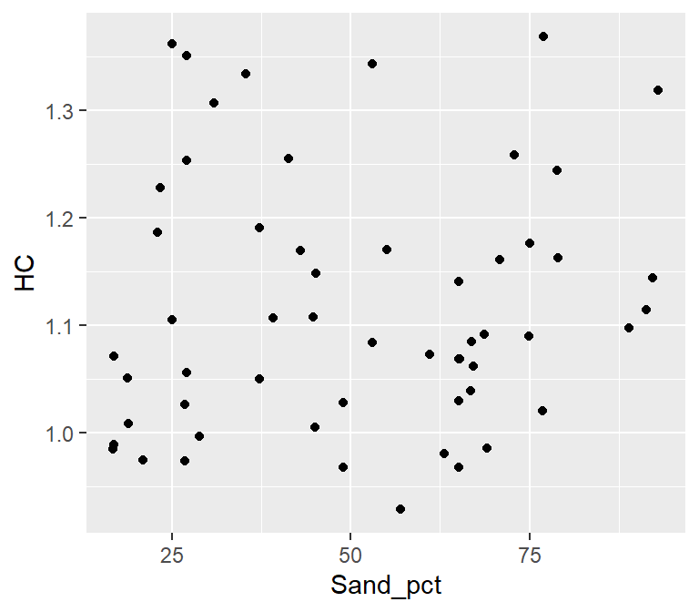

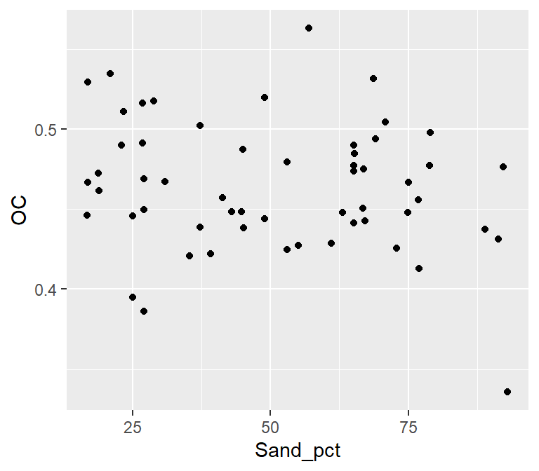

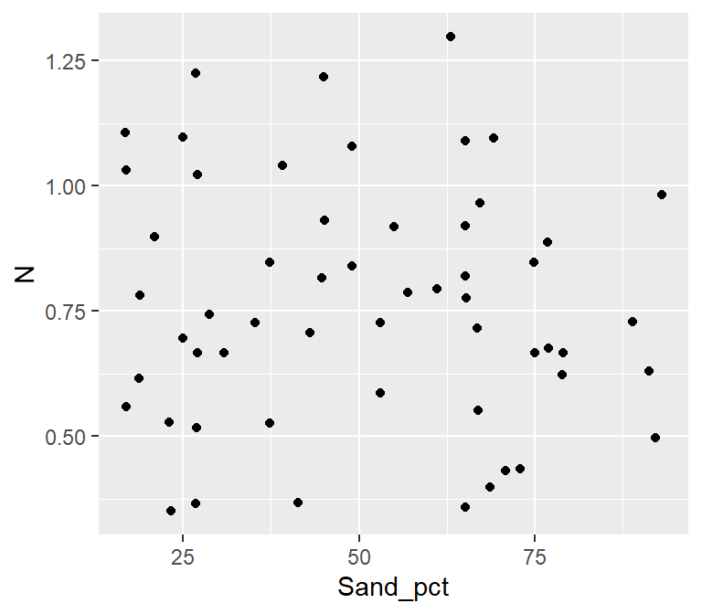